# Item Response Theory

Lukas Weixler

06/02/2021

### Goals of today’s session

- Understand why we apply CTT and IRT in practice
- Interpret the alpha values from CTT
- Obtain a bidimensional and multidimensional Rasch model for a latent construct
- Interpret IRT plots

### Preparations

If you encounter any loading issues install the packages via install.packages()

```r
pacman::p_load(tidyverse, naniar, mice, mitools, purrr, psych)

refs <- read.csv('../SessionData/Polarization/ZA6732_v1-0-0.csv',sep=';')
```

### Practical Steps for binary IRT

1. Name your latent (not clearly quantifiable) construct
2. Name and justify the items (single variables) you use to measure your latent construct
3. Choose the appropriate model based on a set of questions:
- Are units always supposed to follow your ideal ranking?
  - Use Guttman if yes
- - Nonparametric vs parametric? (implies ordinal vs continuous latent variable)
  - Use Rasch if parametric
- Else use Mokken

### Example

- Step 1: Susceptibility to right-wing populist election campaigns
- Step2: Let’s check our polarization dataset:

```r
refs %>%
glimpse()
```

```
## Rows: 2,029
## Columns: 92
## $ za_nr       <int> 6732, 6732, 6732, 6732, 6732, 6732, 6732, 6732, 6732, 6...
## $ version     <chr> "1.0.0 (2019-09-30)", "1.0.0 (2019-09-30)", "1.0.0 (201...
## $ doi         <chr> "doi:10.4232/1.13368", "doi:10.4232/1.13368", "doi:10.4...
## $ FRAME       <chr> "Festnetz", "Festnetz", "Festnetz", "Festnetz", "Festne...
## $ PID         <int> 1, 2, 3, 4, 5, 6, 7, 8, 9, 10, 11, 12, 13, 14, 15, 16, ...
## $ V0A         <chr> "Sachsen", "Nordrhein-Westfalen", "Sachsen", "Nordrhein...
## $ V0C         <chr> "Frage nicht gestellt", "Frage nicht gestellt", "Frage ...
## $ V0B         <chr> "bis 10 000 Einw.", "bis 100 000 Einw.", "bis 2 000 Ein...
## $ V1          <chr> "Ausländer/ Zuwanderung/ Integration/ Asyl/ Flüchtlinge...
## $ V2          <chr> "Renten/ Alte/ Alterssicherung", "Parteien-/ Politikver...
## $ V3          <chr> "AfD", "Linke", "CDU", "FDP", "CDU", "Linke", "CDU", "C...
## $ V4          <chr> "etwas", "etwas", "etwas", "sehr stark", "stark", "star...
## $ V5          <chr> "gut", "gut", "gut", "gut", "gut", "gut", "teils gut/ t...
```

[output cut: 79 more lines]

For our construct we’ll include V30, V31, V33, V39, V41, V43. You may check out the question formulation in the codebook if you want.

### Binarize the responses

Since we still assess only binary outcomes, we’ll have to transform our dataset respectively. For V2_1 and V2_2 we need to get rid of the neutral statements.

```r
refs_opin <- refs %>%

  # Type casting
  mutate_if(is.character, as.factor) %>%

  # Selecting
  select(V30, V31, V33, V39, V41, V43) %>%

  # Renaming
  rename(EU = V43, Refugees = V41, RefugeeService=V39, Marriage = V31, ChildCare = V33, Foreigners = V30) %>%

  # Binarizing through nested ifelse statement
  mutate_all(function(x)
    ifelse(x %in% c('gerade richtig', 'eher Vorteile', 'kulturelle Bereicherung',
                    'eher gut', 'zu wenig getan', 'hat keine großen Auswirkungen',
                    'sollte sich da nicht so viel ändern',
                    'wenn sich die Mitgliedsstaaten künftig enger zusammenschließen'
                    ), 0,
           ifelse(x %in% c('keine Angabe'
                           ), NA,
                  1)
           )
    )
```

### Plotting the missings

Before moving on, let’s check on missings and impute as learned in the last session.

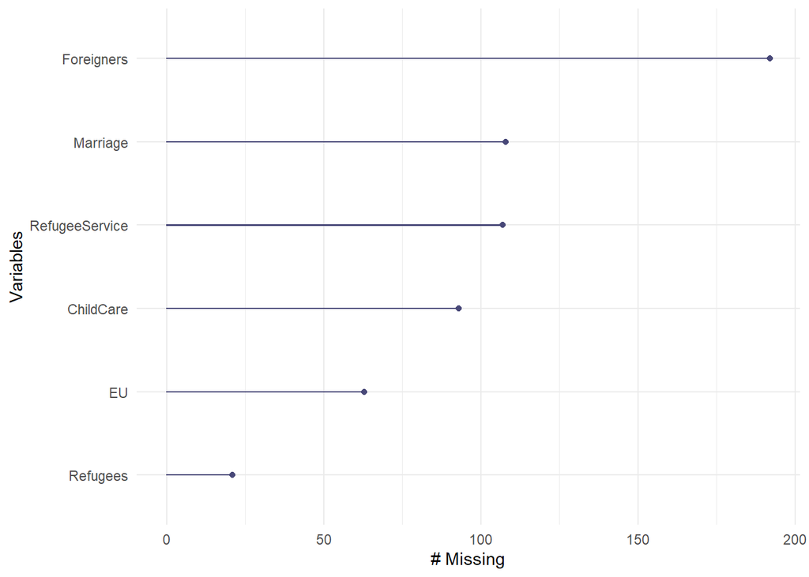

```r
gg_miss_var(refs_opin)
```

### Impute the missings - Check the session on missings for details

```r
# Imputation


# Predictor matrix
pred_matrix <- quickpred(refs_opin)


# Determine method for each column
imp_meth <-
  mice(refs_opin,
     m = 1,
     maxit = 1,
     predictorMatrix = pred_matrix,
       print = FALSE)$method %>%
  as.vector()

# Perform imputation
imp <-
  mice(refs_opin,
       method = imp_meth,
       predictorMatrix = pred_matrix,
       seed = 2020,
       print = FALSE)
```

```r
# Helper function to get the mode of a set of values
getmode <- function(v) {
   uniqv <- unique(v)
   uniqv[which.max(tabulate(match(v, uniqv)))]
}
```

### Obtain imputation dataset through mode calculation for each row

We take the value, which is represented in the majority of the five imputation datasets

```r
imp_refs_opin <- imp %>%
  complete('long', inc=FALSE) %>%
  group_by(.id) %>%
  summarise_all(getmode) %>%
  select(-.id, -.imp)
```

### CTT

Does a set of items measure the same construct? I.e. does a single item correlate to a certain degree with the overall score?

```r
round(cor(imp_refs_opin, use = "pairwise.complete.obs"), 2)
```

```
##                Foreigners Marriage ChildCare RefugeeService Refugees   EU
## Foreigners           1.00     0.26      0.00           0.63     0.35 0.35
## Marriage             0.26     1.00      0.07           0.19     0.17 0.20
## ChildCare            0.00     0.07      1.00           0.02     0.03 0.02
## RefugeeService       0.63     0.19      0.02           1.00     0.36 0.34
## Refugees             0.35     0.17      0.03           0.36     1.00 0.26
## EU                   0.35     0.20      0.02           0.34     0.26 1.00
```

### Interpretation, Optimization

- raw_alpha: *Cronbach’s α (values ≥ .7 or .8 indicate good reliability*; Kline (1999))
- *reliability if one item was dropped*: We consider dropping item if reliability improves.
- raw.r: correlation between the item and the total score from the scale (i.e., item-total correlations); there is a problem with raw.r, that is, the item itself is included in the total—this means we’re correlating the item with itself, so of course it will correlate (r.cor and r.drop solve this problem; see ?alpha for details)
- r.drop: item-total correlation without that item itself (i.e., item-rest correlation or corrected item-total correlation); low item-total correlations indicate that that item doesn’t correlate well with the scale overall
- r.cor: item-total correlation corrected for item overlap and scale reliability mean and sd: mean and sd of the scale if that item is dropped
- All items should correlate the the total score, so we’re looking for items that don’t correlate with the overall score from the scale. *If r.drop values are less than about .3, it means that particular item doesn’t correlate very well with the scale overall*.

Check https://rpubs.com/hauselin/reliabilityanalysis for further details.

```r
refs_alpha <- alpha(imp_refs_opin, na.rm = TRUE)
refs_alpha
```

```
##
## Reliability analysis
## Call: alpha(x = imp_refs_opin, na.rm = TRUE)
##
##   raw_alpha std.alpha G6(smc) average_r S/N  ase mean   sd median_r
##       0.66      0.62    0.62      0.22 1.6 0.01 0.22 0.24      0.2
##
##  lower alpha upper     95% confidence boundaries
## 0.64 0.66 0.68
##
##  Reliability if an item is dropped:
##                raw_alpha std.alpha G6(smc) average_r  S/N alpha se var.r med.r
## Foreigners          0.53      0.49    0.47      0.16 0.98    0.015 0.017  0.18
## Marriage            0.66      0.60    0.61      0.23 1.53    0.010 0.044  0.30
## ChildCare           0.69      0.69    0.67      0.31 2.24    0.010 0.018  0.30
## RefugeeService      0.54      0.51    0.48      0.17 1.03    0.014 0.018  0.18
## Refugees            0.62      0.57    0.57      0.21 1.30    0.012 0.039  0.19
## EU                  0.61      0.57    0.57      0.21 1.30    0.012 0.039  0.18
##
##  Item statistics
##                   n raw.r std.r r.cor r.drop  mean   sd
## Foreigners     2029  0.79  0.73 0.729  0.596 0.381 0.49
## Marriage       2029  0.54  0.53 0.351  0.287 0.233 0.42
## ChildCare      2029  0.16  0.32 0.051  0.038 0.034 0.18
## RefugeeService 2029  0.76  0.72 0.701  0.565 0.310 0.46
## Refugees       2029  0.57  0.61 0.477  0.402 0.111 0.31
## EU             2029  0.64  0.61 0.478  0.405 0.279 0.45
##
## Non missing response frequency for each item
##                   0    1 miss
## Foreigners     0.62 0.38    0
## Marriage       0.77 0.23    0
## ChildCare      0.97 0.03    0
## RefugeeService 0.69 0.31    0
## Refugees       0.89 0.11    0
## EU             0.72 0.28    0
```

### Omit ChildCare and Marriage variables

```r
reduced_dat <- imp_refs_opin %>% select(-ChildCare, -Marriage)

alpha(reduced_dat, na.rm = TRUE)
```

```
##
## Reliability analysis
## Call: alpha(x = reduced_dat, na.rm = TRUE)
##
##   raw_alpha std.alpha G6(smc) average_r S/N  ase mean   sd median_r
##       0.71      0.71    0.67      0.38 2.4 0.01 0.27 0.32     0.35
##
##  lower alpha upper     95% confidence boundaries
## 0.69 0.71 0.73
##
##  Reliability if an item is dropped:
##                raw_alpha std.alpha G6(smc) average_r S/N alpha se  var.r med.r
## Foreigners          0.57      0.58    0.49      0.32 1.4    0.016 0.0029  0.34
## RefugeeService      0.57      0.58    0.49      0.32 1.4    0.016 0.0028  0.35
## Refugees            0.70      0.70    0.64      0.44 2.3    0.011 0.0266  0.35
## EU                  0.71      0.71    0.64      0.44 2.4    0.010 0.0253  0.36
##
##  Item statistics
##                   n raw.r std.r r.cor r.drop mean   sd
## Foreigners     2029  0.82  0.79  0.73   0.61 0.38 0.49
## RefugeeService 2029  0.81  0.79  0.73   0.61 0.31 0.46
## Refugees       2029  0.60  0.67  0.47   0.40 0.11 0.31
## EU             2029  0.68  0.67  0.46   0.40 0.28 0.45
##
## Non missing response frequency for each item
##                   0    1 miss
## Foreigners     0.62 0.38    0
## RefugeeService 0.69 0.31    0
## Refugees       0.89 0.11    0
## EU             0.72 0.28    0
```

### IRT

Method originally comes from education research: - Which item is more “difficult”? - Here: Which item depicts a stronger Susceptibility to right-wing populist election campaigns? - For a valid ordering, we ’d furthermore assume, that if a respondent’s answer is positive on a strong question, he’d also answer positive on a weaker question.

### Further imports here due to conflicts

```r
pacman::p_load(ltm, mitools,mice,eRm, diffr, mirt, psych)
```

### Step 3: Chosing the best model:

- Are units always supposed to follow your ideal ranking?
  - Use Guttman if yes #### No
- Nonparametric vs parametric? (implies ordinal vs continuous latent variable) #### Parametric
  - Use Rasch if yes
- Else use Mokken

### Obtain Rasch model for first dataset

```r
#refs_opin_imp <- imp_data$imputations[[1]]
```

### Using the Rasch model on our four items

Item difficulty shows: Foreigners question is easiest, personal disadvantage due to refugees is hardest, foreigners is easiest

```r
model1 <- RM(reduced_dat)
betas <- -coef(model1)
sort(betas)
```

```
##     beta Foreigners beta RefugeeService             beta EU       beta Refugees
##          -1.0145191          -0.4366147          -0.1698413           1.6209750
```

# Plotting the joint Item Characteristic Curves

They depict the probabilities for a positive answer, depending on their latent dimension (number of positive responses). Note that the replacement of neutrals with positives lets our V2 Variables look more powerful (i.e. if a participant is positive on V3c and V1b he should also be positive on the others).

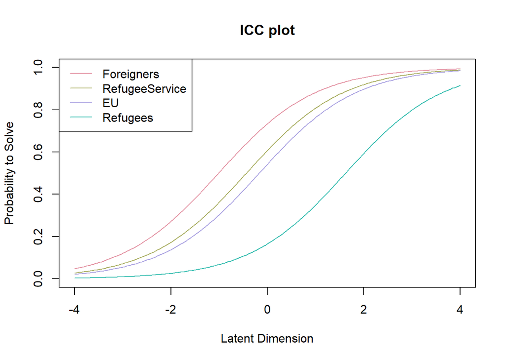

```r
plotjointICC(model1, item.subset = 1:4)
```

# Plot the person-item map

This map displays the location of an item as well as the distribution of person parameters along the latent dimension (in our case opinion towards refugee policy). We may compare this to the overall person-parameter distribution. Execute `?plotPImap` for more information.

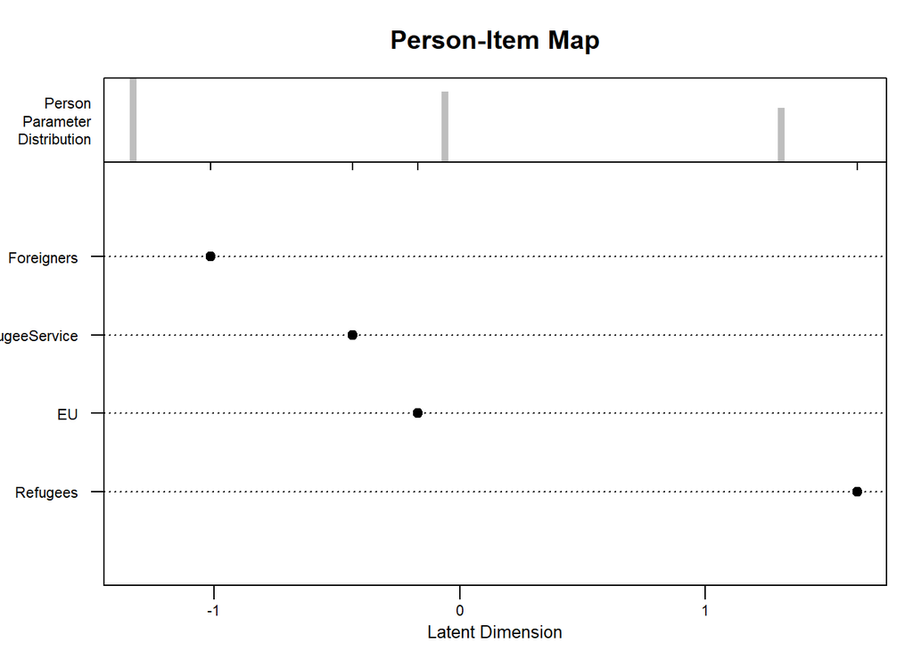

```r
plotPImap(model1, sorted=TRUE)
```

### Further IRT: Look at Guttman, Mokken and non-binaries

https://hansjoerg.me/2018/04/23/rasch-in-r-tutorial/

They also present an advanced approach: Multi-Factor modelling - if we had more than two factors, this might be a reasonable approach. Nevertheless, out of the very narrow field of social science surveys, this is barely used.